# Regression Models

```r
set.seed(123)
```

## Example 2.1: Munich Rent Index - Simple Linear Regression

Importing the dataset as in 01 Introduction.rmd, but using the R script available in `import_data/munich_rent_index.R`:

```r
source("import_data/munich_rent_index.R")
```

Filtering by apartments build after 1966:

```r
rent_1966 <- subset(munich_rent_index, yearc >= 1966)

summary(rent_1966)
```

```
      rent           rentsqm            area            yearc      location
 Min.   : 133.3   Min.   : 1.926   Min.   : 20.00   Min.   :1966   1:768
 1st Qu.: 368.2   1st Qu.: 6.618   1st Qu.: 48.00   1st Qu.:1971   2:346
 Median : 482.6   Median : 8.216   Median : 63.00   Median :1973   3: 37
 Mean   : 508.7   Mean   : 8.242   Mean   : 63.92   Mean   :1978
 3rd Qu.: 610.1   3rd Qu.: 9.783   3rd Qu.: 80.00   3rd Qu.:1984
 Max.   :1517.9   Max.   :17.722   Max.   :154.00   Max.   :1997

    bath          kitchen         cheating          district
 Mode :logical   Mode :logical   Mode :logical   2024   :  28
 FALSE:1050      FALSE:1070      FALSE:7         711    :  24
 TRUE :101       TRUE :81        TRUE :1144      1012   :  21
                                                 1013   :  21
                                                 2221   :  21
                                                 1942   :  16
                                                 (Other):1020
```

And use only average locations:

```r
av_rent_1966 <- subset(rent_1966, location == 1)

summary(av_rent_1966)
```

```
      rent           rentsqm            area            yearc      location
 Min.   : 133.3   Min.   : 2.077   Min.   : 20.00   Min.   :1966   1:768
 1st Qu.: 359.4   1st Qu.: 6.344   1st Qu.: 48.00   1st Qu.:1971   2:  0
 Median : 466.3   Median : 7.892   Median : 63.00   Median :1972   3:  0
 Mean   : 484.8   Mean   : 7.902   Mean   : 63.62   Mean   :1977
 3rd Qu.: 578.6   3rd Qu.: 9.291   3rd Qu.: 79.00   3rd Qu.:1984
 Max.   :1459.2   Max.   :14.872   Max.   :154.00   Max.   :1997

    bath          kitchen         cheating          district
 Mode :logical   Mode :logical   Mode :logical   2024   : 28
 FALSE:714       FALSE:710       FALSE:1         1012   : 21
 TRUE :54        TRUE :58        TRUE :767       1013   : 21
                                                 2221   : 20
                                                 1942   : 16
                                                 1641   : 15
                                                 (Other):647
```

Then the simple linear regression model is given by

$$\mathbb{E}({\text{rent}}) = \beta_{0} + \beta_{1} \cdot \text{area}$$

```r
simple_model <- lm(rent ~ area, data = av_rent_1966)

summary(simple_model)
```

```
Call:
lm(formula = rent ~ area, data = av_rent_1966)

Residuals:
    Min      1Q  Median      3Q     Max
-434.36  -81.23   -2.23   80.08  549.11

Coefficients:
            Estimate Std. Error t value Pr(>|t|)
(Intercept) 130.2334    14.2884   9.115   <2e-16 ***
area          5.5729     0.2133  26.128   <2e-16 ***
---
Signif. codes:  0 '***' 0.001 '**' 0.01 '*' 0.05 '.' 0.1 ' ' 1

Residual standard error: 123.9 on 766 degrees of freedom
Multiple R-squared:  0.4712,    Adjusted R-squared:  0.4705
F-statistic: 682.7 on 1 and 766 DF,  p-value: < 2.2e-16
```

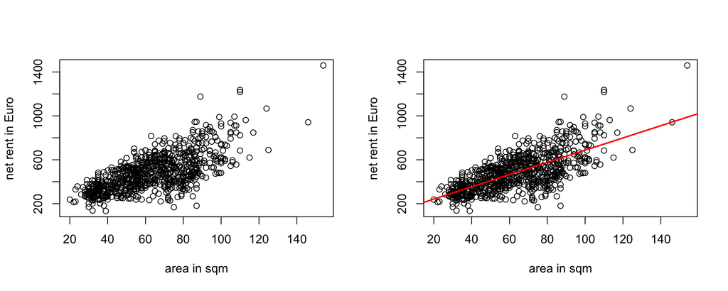

```r
par(mfrow = c(1, 2))

plot(
  x = av_rent_1966$area,
  y = av_rent_1966$rent,
  xlab = 'area in sqm',
  ylab = 'net rent in Euro'
)

plot(
  x = av_rent_1966$area,
  y = av_rent_1966$rent,
  xlab = 'area in sqm',
  ylab = 'net rent in Euro'
)
abline(simple_model, col = "red", lwd=2)
```

## Example 2.2: Munich Rent Index - Simple Linear Regression

Choosing the rent per square meter as response variable, we have the model:

$$\mathbb{E}(\text{rent per sqm}) = \beta_{0} + \beta_{1} \cdot
\text{area}$$

```r
per_sqm_model <- lm(rentsqm ~ area, data = av_rent_1966)

summary(per_sqm_model)
```

```
Call:
lm(formula = rentsqm ~ area, data = av_rent_1966)

Residuals:
    Min      1Q  Median      3Q     Max
-5.4874 -1.4274 -0.0734  1.2813  6.3396

Coefficients:
             Estimate Std. Error t value Pr(>|t|)
(Intercept) 10.497332   0.219984   47.72   <2e-16 ***
area        -0.040797   0.003284  -12.42   <2e-16 ***
---
Signif. codes:  0 '***' 0.001 '**' 0.01 '*' 0.05 '.' 0.1 ' ' 1

Residual standard error: 1.908 on 766 degrees of freedom
Multiple R-squared:  0.1677,    Adjusted R-squared:  0.1666
F-statistic: 154.3 on 1 and 766 DF,  p-value: < 2.2e-16
```

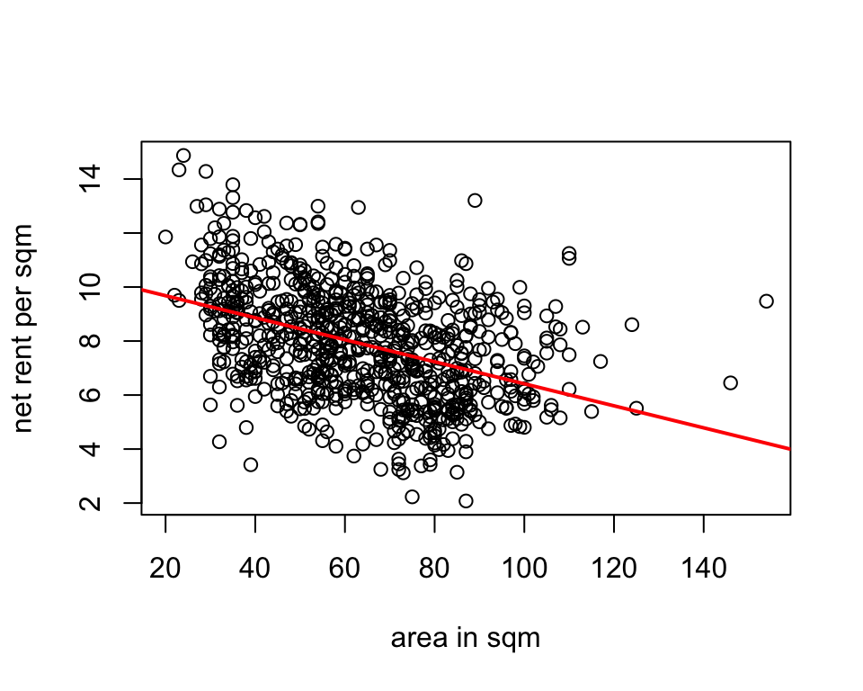

```r
plot(
  x = av_rent_1966$area,
  y = av_rent_1966$rentsqm,
  xlab = 'area in sqm',
  ylab = 'net rent per sqm'
)
abline(per_sqm_model, col = "red", lwd=2)
```

We change the variable

$$x = \frac{1}{\text{area}}$$

Giving us the model:

$$\mathbb{E}(\text{rent per sqm}) = \beta_{0} + \beta_{1} \cdot x =
\beta_{0} + \beta_{1} \cdot \frac{1}{\text{area}}$$

```r
av_rent_1966$inv_area <- 1 / av_rent_1966$area

per_sqm_inv_model <- lm(rentsqm ~ inv_area, data = av_rent_1966)

summary(per_sqm_inv_model)
```

```
Call:
lm(formula = rentsqm ~ inv_area, data = av_rent_1966)

Residuals:
    Min      1Q  Median      3Q     Max
-5.5730 -1.4152 -0.0508  1.3200  6.2068

Coefficients:
            Estimate Std. Error t value Pr(>|t|)
(Intercept)   5.4449     0.1901   28.64   <2e-16 ***
inv_area    138.3266    10.0067   13.82   <2e-16 ***
---
Signif. codes:  0 '***' 0.001 '**' 0.01 '*' 0.05 '.' 0.1 ' ' 1

Residual standard error: 1.871 on 766 degrees of freedom
Multiple R-squared:  0.1997,    Adjusted R-squared:  0.1986
F-statistic: 191.1 on 1 and 766 DF,  p-value: < 2.2e-16
```

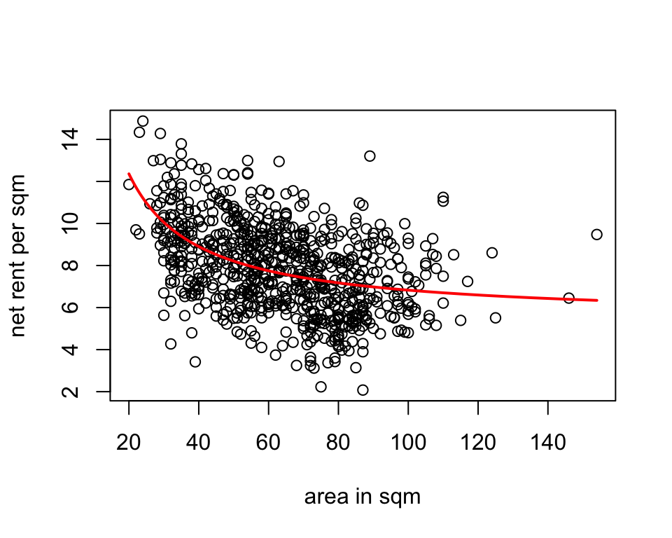

```r
plot(
  x = av_rent_1966$area,
  y = av_rent_1966$rentsqm,
  xlab = 'area in sqm',
  ylab = 'net rent per sqm'
)
x_seq <- seq(min(1 / av_rent_1966$area), max(1 / av_rent_1966$area), length.out = 100)
predicted <- predict(per_sqm_inv_model, newdata = data.frame(inv_area = x_seq))

lines(1 / x_seq, predicted, col = "red", lwd = 2)
```

## Example 2.3: Munich Rent Index - Rent in Average and Good Localtions

We add the variable $\text{good location}$ to the model:

$$\mathbb{E}(\text{rent}) = \beta_{0} + \beta_{1} \cdot \text{area} +
\beta_{2} \cdot \text{good localtion}$$

```r
ag_rent_1966 <- subset(rent_1966, location %in% c(1, 2))
summary(ag_rent_1966)
```

```
      rent           rentsqm            area            yearc      location
 Min.   : 133.3   Min.   : 1.926   Min.   : 20.00   Min.   :1966   1:768
 1st Qu.: 367.8   1st Qu.: 6.578   1st Qu.: 48.00   1st Qu.:1971   2:346
 Median : 479.3   Median : 8.166   Median : 63.00   Median :1973   3:  0
 Mean   : 502.0   Mean   : 8.201   Mean   : 63.53   Mean   :1978
 3rd Qu.: 601.1   3rd Qu.: 9.727   3rd Qu.: 79.00   3rd Qu.:1984
 Max.   :1517.9   Max.   :17.722   Max.   :154.00   Max.   :1997

    bath          kitchen         cheating          district
 Mode :logical   Mode :logical   Mode :logical   2024   : 28
 FALSE:1020      FALSE:1035      FALSE:6         711    : 24
 TRUE :94        TRUE :79        TRUE :1108      1012   : 21
                                                 1013   : 21
                                                 2221   : 21
                                                 1942   : 16
                                                 (Other):983
```

```r
ag_rent_1966$glocation <- ag_rent_1966$location == 2
summary(ag_rent_1966)
```

```
      rent           rentsqm            area            yearc      location
 Min.   : 133.3   Min.   : 1.926   Min.   : 20.00   Min.   :1966   1:768
 1st Qu.: 367.8   1st Qu.: 6.578   1st Qu.: 48.00   1st Qu.:1971   2:346
 Median : 479.3   Median : 8.166   Median : 63.00   Median :1973   3:  0
 Mean   : 502.0   Mean   : 8.201   Mean   : 63.53   Mean   :1978
 3rd Qu.: 601.1   3rd Qu.: 9.727   3rd Qu.: 79.00   3rd Qu.:1984
 Max.   :1517.9   Max.   :17.722   Max.   :154.00   Max.   :1997

    bath          kitchen         cheating          district   glocation
 Mode :logical   Mode :logical   Mode :logical   2024   : 28   Mode :logical
 FALSE:1020      FALSE:1035      FALSE:6         711    : 24   FALSE:768
 TRUE :94        TRUE :79        TRUE :1108      1012   : 21   TRUE :346
                                                 1013   : 21
                                                 2221   : 21
                                                 1942   : 16
                                                 (Other):983
```

```r
good_model <- lm(rent ~ area + glocation, data = ag_rent_1966)
summary(good_model)
```

```
Call:
lm(formula = rent ~ area + glocation, data = ag_rent_1966)

Residuals:
    Min      1Q  Median      3Q     Max
-497.96  -82.28    0.42   81.37  611.07

Coefficients:
              Estimate Std. Error t value Pr(>|t|)
(Intercept)    112.686     12.973   8.686  < 2e-16 ***
area             5.849      0.189  30.942  < 2e-16 ***
glocationTRUE   57.261      8.727   6.561 8.15e-11 ***
---
Signif. codes:  0 '***' 0.001 '**' 0.01 '*' 0.05 '.' 0.1 ' ' 1

Residual standard error: 134.8 on 1111 degrees of freedom
Multiple R-squared:  0.4732,    Adjusted R-squared:  0.4722
F-statistic: 498.9 on 2 and 1111 DF,  p-value: < 2.2e-16
```

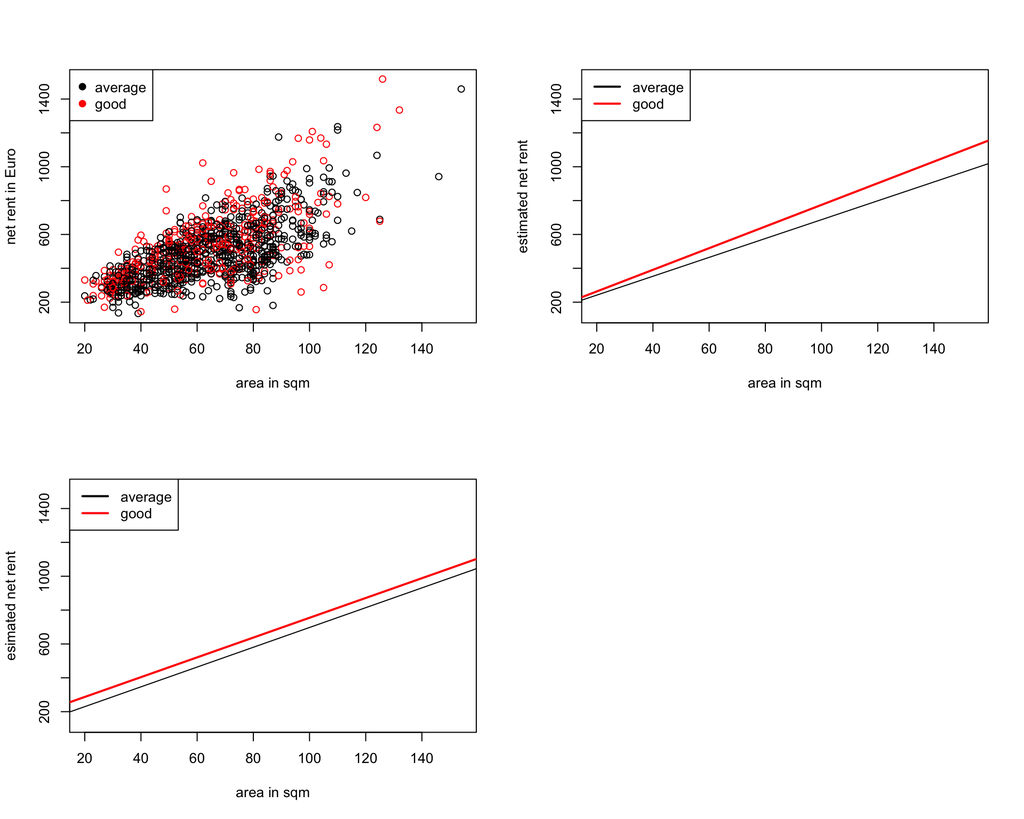

```r
par(mfrow = c(2, 2))

colors <- c("black", "red")

plot(
    x = ag_rent_1966$area,
    y = ag_rent_1966$rent,
    xlab = 'area in sqm',
    ylab = 'net rent in Euro',
    col = colors[as.numeric(ag_rent_1966$location)]
)

legend(
  "topleft",
  legend = c('average', 'good'),
  col = colors,
  pch = 19
)

g_rent_1966 <- subset(rent_1966, location == 2)
simple_good_model <- lm(rent ~ area, data = g_rent_1966)

plot(NA, xlim = range(rent_1966$area), ylim = range(rent_1966$rent), xlab = 'area in sqm', ylab = 'estimated net rent')
abline(simple_model)
abline(simple_good_model, col = "red", lwd = 2)

legend(
  "topleft",
  legend = c('average', 'good'),
  col = c('black', 'red'),
  lwd = 2
)

plot(NA, xlim = range(rent_1966$area), ylim = range(rent_1966$rent), xlab = 'area in sqm', ylab = 'esimated net rent')

beta <- good_model$coefficients

abline(beta[1], beta[2])
abline(beta[1] + beta[3], beta[2], col = "red", lwd = 2)

legend(
  "topleft",
  legend = c('average', 'good'),
  col = c('black', 'red'),
  lwd = 2
)
```

## Example 2.4 Munich Rent Index — Nonlinear Influence of Living Area

We add the good location dummy variable to the model of example 2.2:

$$\mathbb{E}(\text{rent per sqm}) = \beta_{0} + \beta_{1} \cdot
\frac{1}{\text{area}} + \beta_{2} \cdot \text{good location}$$

```r
g_multiple_model <- lm(rentsqm ~ I(1/area) + glocation, data = ag_rent_1966)
summary(g_multiple_model)
```

```
Call:
lm(formula = rentsqm ~ I(1/area) + glocation, data = ag_rent_1966)

Residuals:
    Min      1Q  Median      3Q     Max
-6.1795 -1.4137 -0.0329  1.3489  8.5672

Coefficients:
              Estimate Std. Error t value Pr(>|t|)
(Intercept)     5.5090     0.1668  33.028  < 2e-16 ***
I(1/area)     134.7204     8.4686  15.908  < 2e-16 ***
glocationTRUE   0.8961     0.1295   6.922 7.53e-12 ***
---
Signif. codes:  0 '***' 0.001 '**' 0.01 '*' 0.05 '.' 0.1 ' ' 1

Residual standard error: 1.998 on 1111 degrees of freedom
Multiple R-squared:  0.2173,    Adjusted R-squared:  0.2159
F-statistic: 154.2 on 2 and 1111 DF,  p-value: < 2.2e-16
```

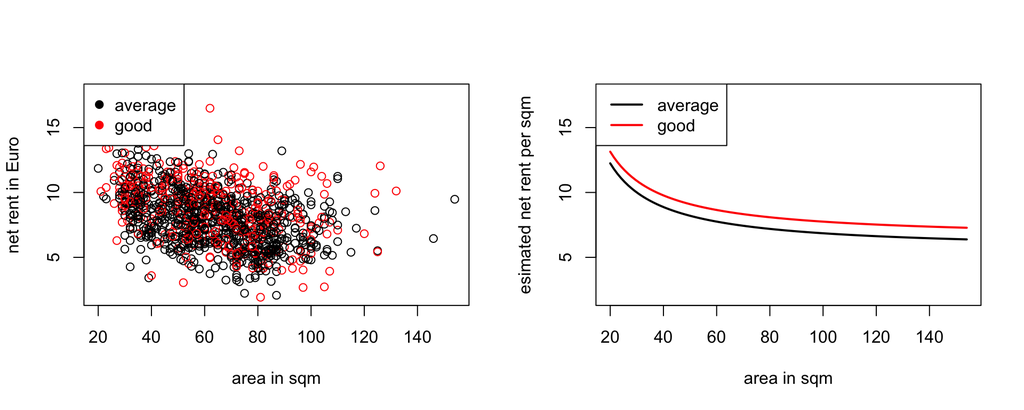

```r
par(mfrow = c(1, 2))

colors <- c("black", "red")

plot(
    x = ag_rent_1966$area,
    y = ag_rent_1966$rentsqm,
    xlab = 'area in sqm',
    ylab = 'net rent in Euro',
    col = colors[as.numeric(ag_rent_1966$location)]
)

legend(
  "topleft",
  legend = c('average', 'good'),
  col = colors,
  pch = 19
)

plot(NA, xlim = range(rent_1966$area), ylim = range(rent_1966$rentsqm), xlab = 'area in sqm', ylab = 'esimated net rent per sqm')

x_seq <- seq(min(ag_rent_1966$area), max(ag_rent_1966$area), length.out = 100)
beta <- g_multiple_model$coefficients

lines(x_seq, beta[1] + beta[2] * (1/x_seq), col = 'black', lwd = 2)
lines(x_seq, beta[1] + beta[2] * (1/x_seq) + beta[3], col = 'red', lwd = 2)

legend(
  "topleft",
  legend = c('average', 'good'),
  col = c('black', 'red'),
  lwd = 2
)
```

## Example 2.5 Munich Rent Index — Interaction Between Living Area and Location

Adding the interaction term between area and good location:

$$\mathbb{E}(\text{rent}) = \beta_{0} + \beta_{1} \cdot \text{area} +
\beta_{2} \cdot \text{good location} + \beta_{3} \cdot
\text{interaction}$$

```r
ag_rent_1966$inter <- ag_rent_1966$area * as.numeric(ag_rent_1966$glocation)

summary(ag_rent_1966$inter)
```

```
   Min. 1st Qu.  Median    Mean 3rd Qu.    Max.
   0.00    0.00    0.00   19.67   41.00  132.00
```

```r
g_inter_model <- lm(rent ~ area + glocation + inter, data = ag_rent_1966)
summary(g_inter_model)
```

```
Call:
lm(formula = rent ~ area + glocation + inter, data = ag_rent_1966)

Residuals:
    Min      1Q  Median      3Q     Max
-520.67  -81.88   -1.22   80.68  576.91

Coefficients:
              Estimate Std. Error t value Pr(>|t|)
(Intercept)   130.2334    15.5173   8.393   <2e-16 ***
area            5.5729     0.2316  24.058   <2e-16 ***
glocationTRUE   5.2053    26.7999   0.194   0.8460
inter           0.8208     0.3996   2.054   0.0402 *
---
Signif. codes:  0 '***' 0.001 '**' 0.01 '*' 0.05 '.' 0.1 ' ' 1

Residual standard error: 134.6 on 1110 degrees of freedom
Multiple R-squared:  0.4752,    Adjusted R-squared:  0.4737
F-statistic:   335 on 3 and 1110 DF,  p-value: < 2.2e-16
```

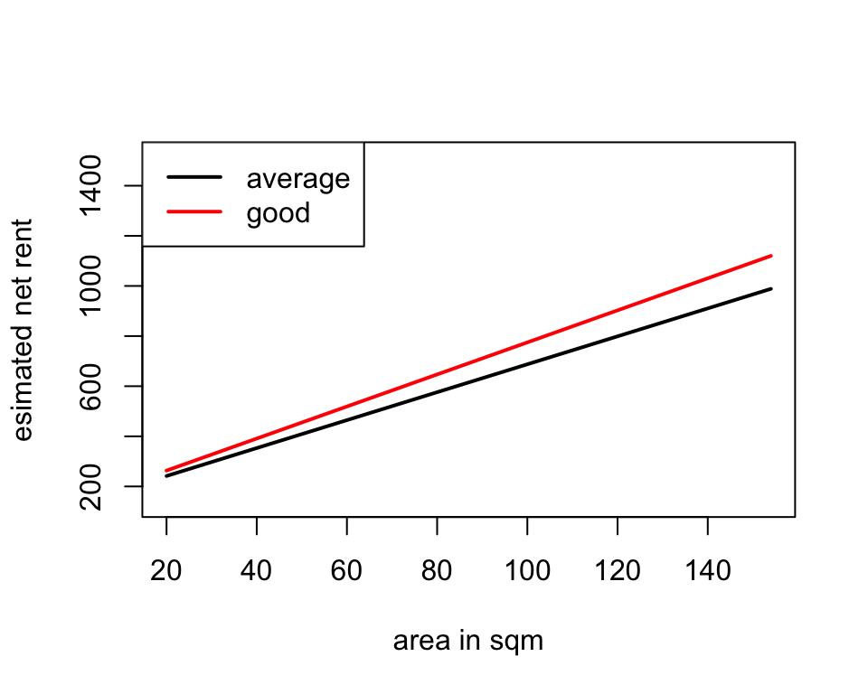

```r
plot(NA, xlim = range(ag_rent_1966$area), ylim = range(ag_rent_1966$rent), xlab = 'area in sqm', ylab = 'esimated net rent')

x_seq <- seq(min(ag_rent_1966$area), max(ag_rent_1966$area), length.out = 100)
beta <- g_inter_model$coefficients

lines(x_seq, beta[1] + beta[2] * x_seq, col = 'black', lwd = 2)
lines(x_seq, beta[1] + (beta[2] + beta[4]) * x_seq + beta[3], col = 'red', lwd = 2)

legend(
  "topleft",
  legend = c('average', 'good'),
  col = c('black', 'red'),
  lwd = 2
)
```

## Example 2.6 Munich Rent Index — Multiple Regression Model

Now we add the top location ($\text{location} = 3$):

```r
munich_rent_index$glocation <- munich_rent_index$location == 2
munich_rent_index$tlocation <- munich_rent_index$location == 3
summary(munich_rent_index)
```

```
      rent            rentsqm             area            yearc      location
 Min.   :  40.51   Min.   : 0.4158   Min.   : 20.00   Min.   :1918   1:1794
 1st Qu.: 322.03   1st Qu.: 5.2610   1st Qu.: 51.00   1st Qu.:1939   2:1210
 Median : 426.97   Median : 6.9802   Median : 65.00   Median :1959   3:  78
 Mean   : 459.44   Mean   : 7.1113   Mean   : 67.37   Mean   :1956
 3rd Qu.: 559.36   3rd Qu.: 8.8408   3rd Qu.: 81.00   3rd Qu.:1972
 Max.   :1843.38   Max.   :17.7216   Max.   :160.00   Max.   :1997

    bath          kitchen         cheating          district    glocation
 Mode :logical   Mode :logical   Mode :logical   411    :  53   Mode :logical
 FALSE:2891      FALSE:2951      FALSE:321       623    :  53   FALSE:1872
 TRUE :191       TRUE :131       TRUE :2761      350    :  49   TRUE :1210
                                                 563    :  49
                                                 711    :  42
                                                 360    :  38
                                                 (Other):2798
 tlocation
 Mode :logical
 FALSE:3004
 TRUE :78
```

A multiple model with all available variables:

$$\begin{matrix}
\mathbb{E}(\text{rentsqm}) = & \beta_{0} + \beta_{1} \cdot
\frac{1}{\text{area}} + \beta_{2} \cdot \text{yearc} + \beta_{3} \cdot
\text{yearc}^2 + \beta_{4} \cdot \text{good location} + \beta_{5} \cdot
\text{top location} \\
& + \beta_{6} \cdot \text{bath} + \beta_{7} \cdot \text{kitchen} +
\beta_{8} \cdot \text{cheating} \\
\end{matrix}$$

```r
multiple_model <- lm(rentsqm ~ I(1/area) + yearc + I(yearc^2) + glocation + tlocation + bath + kitchen + cheating, data = munich_rent_index)
summary(multiple_model)
```

```
Call:
lm(formula = rentsqm ~ I(1/area) + yearc + I(yearc^2) + glocation +
    tlocation + bath + kitchen + cheating, data = munich_rent_index)

Residuals:
    Min      1Q  Median      3Q     Max
-7.0080 -1.2651 -0.0558  1.2261  8.0095

Coefficients:
                Estimate Std. Error t value Pr(>|t|)
(Intercept)    3.685e+03  2.681e+02  13.745  < 2e-16 ***
I(1/area)      1.375e+02  5.303e+00  25.929  < 2e-16 ***
yearc         -3.801e+00  2.747e-01 -13.838  < 2e-16 ***
I(yearc^2)     9.805e-04  7.033e-05  13.941  < 2e-16 ***
glocationTRUE  6.795e-01  7.276e-02   9.340  < 2e-16 ***
tlocationTRUE  1.519e+00  2.227e-01   6.819 1.10e-11 ***
bathTRUE       5.027e-01  1.472e-01   3.416 0.000644 ***
kitchenTRUE    8.665e-01  1.752e-01   4.945 8.02e-07 ***
cheatingTRUE   1.870e+00  1.229e-01  15.225  < 2e-16 ***
---
Signif. codes:  0 '***' 0.001 '**' 0.01 '*' 0.05 '.' 0.1 ' ' 1

Residual standard error: 1.921 on 3073 degrees of freedom
Multiple R-squared:   0.38, Adjusted R-squared:  0.3783
F-statistic: 235.4 on 8 and 3073 DF,  p-value: < 2.2e-16
```

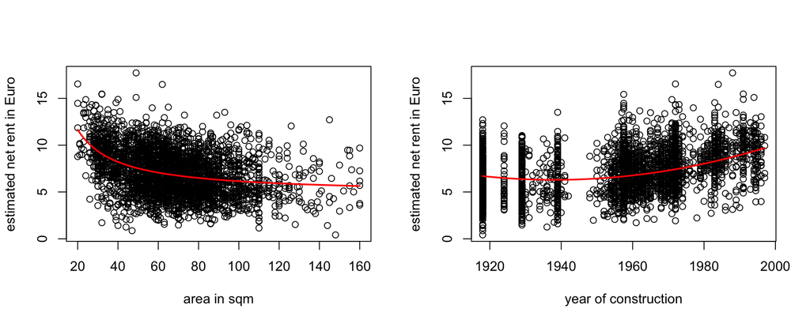

```r
par(mfrow = c(1, 2))

plot(
    x = munich_rent_index$area,
    y = munich_rent_index$rentsqm,
    xlab = 'area in sqm',
    ylab = 'estimated net rent in Euro',
)

area_seq <- seq(min(munich_rent_index$area), max(munich_rent_index$area), length.out = 100)
beta <- multiple_model$coefficients

constant <- beta[5] * mean(as.numeric(munich_rent_index$glocation)) +
  beta[6] * mean(as.numeric(munich_rent_index$tlocation)) +
  beta[7] * mean(as.numeric(munich_rent_index$bath)) +
  beta[8] * mean(as.numeric(munich_rent_index$kitchen)) +
  beta[9] * mean(as.numeric(munich_rent_index$cheating))

year_constant <- beta[3] * mean(munich_rent_index$yearc) + beta[4] * mean(munich_rent_index$yearc^2)

lines(area_seq, beta[1] + beta[2] * (1 / area_seq) + constant + year_constant, col = 'red', lwd = 2)

plot(
    x = munich_rent_index$yearc,
    y = munich_rent_index$rentsqm,
    xlab = 'year of construction',
    ylab = 'estimated net rent in Euro',
)

area_constant <- beta[2] * mean(1 / munich_rent_index$area)

year_seq <- seq(min(munich_rent_index$yearc), max(munich_rent_index$yearc), length.out = 100)
lines(year_seq, beta[1] + beta[3] * year_seq + beta[4] * year_seq^2 + constant + area_constant, col = 'red', lwd = 2)
```

## Example 2.7 Patent Opposition

Import the patent opposition from script:

```r
source("import_data/patent_opposition.R")
```

We left the $\text{opp}$ dataset as integer, so we can model the response variable as binary:

```r
patent_opposition$opp <- as.integer(patent_opposition$opp == 1)
summary(patent_opposition$opp)
```

```
   Min. 1st Qu.  Median    Mean 3rd Qu.    Max.
 0.0000  0.0000  0.0000  0.4149  1.0000  1.0000
```

## Example 2.8: Patent Opposition

We explore the histogram of claims ($\text{nclaims}$) and citations ($\text{ncit}$):

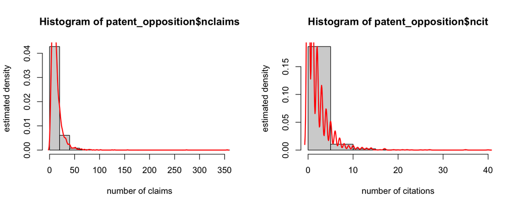

```r
par(mfrow = c(1, 2))

hist(patent_opposition$nclaims, ylab = 'estimated density', xlab = 'number of claims', freq = FALSE)
lines(density(patent_opposition$nclaims), col = 'red', lwd = 2)

hist(patent_opposition$ncit, ylab = 'estimated density', xlab = 'number of citations', freq = FALSE)
lines(density(patent_opposition$ncit), col = 'red', lwd = 2)
```

```r
deoutlier_patent_opp <- subset(patent_opposition, nclaims <= 60 & ncit <= 15)
not_biopharm_patent_opp <- subset(deoutlier_patent_opp, biopharm == 0)
summary(not_biopharm_patent_opp)
```

```
      opp         biopharm         ustwin          patus
 Min.   :0.000   Mode :logical   Mode :logical   Mode :logical
 1st Qu.:0.000   FALSE:2702      FALSE:719       FALSE:1886
 Median :0.000                   TRUE :1983      TRUE :816
 Mean   :0.282
 3rd Qu.:1.000
 Max.   :1.000
  patgsgr             year           ncit           ncountry
 Mode :logical   Min.   :1980   Min.   : 0.000   Min.   : 1.000
 FALSE:2118      1st Qu.:1988   1st Qu.: 0.000   1st Qu.: 3.000
 TRUE :584       Median :1992   Median : 1.000   Median : 4.000
                 Mean   :1991   Mean   : 1.387   Mean   : 5.329
                 3rd Qu.:1994   3rd Qu.: 2.000   3rd Qu.: 6.000
                 Max.   :1997   Max.   :14.000   Max.   :17.000
    nclaims
 Min.   : 1.00
 1st Qu.: 6.00
 Median : 9.00
 Mean   :10.84
 3rd Qu.:13.00
 Max.   :60.00
```

We then fit the logistic regression model:

$$P(\text{opp}_{i} = 1) = \frac{\exp(\eta_{i})}{1 + \exp(\eta_{i})}$$

$$\eta_{i} = \beta_{0} + \beta_{1} \cdot \text{year}_{i} + \beta_{2} \cdot
\text{ncit}_{i} + \beta_{3} \cdot \text{nclaims}_{i} + \beta_{4} \cdot
\text{ustwin}_{i} + \beta_{5} \cdot \text{patus}_{i} + \beta_{6} \cdot
\text{patgsgr}_{i} + \beta_{7} \cdot \text{ncountry}_{i}$$

```r
pat_opp_model <- glm(opp ~ year + ncit + nclaims + ustwin + patus + patgsgr + ncountry, data = not_biopharm_patent_opp, family = binomial)
summary(pat_opp_model)
```

```
Call:
glm(formula = opp ~ year + ncit + nclaims + ustwin + patus +
    patgsgr + ncountry, family = binomial, data = not_biopharm_patent_opp)

Coefficients:
              Estimate Std. Error z value Pr(>|z|)
(Intercept) 201.739764  22.321279   9.038  < 2e-16 ***
year         -0.102127   0.011217  -9.105  < 2e-16 ***
ncit          0.113558   0.022304   5.091 3.55e-07 ***
nclaims       0.026575   0.005922   4.488 7.20e-06 ***
ustwinTRUE   -0.402600   0.099963  -4.028 5.64e-05 ***
patusTRUE    -0.526343   0.112599  -4.675 2.95e-06 ***
patgsgrTRUE   0.196654   0.117388   1.675   0.0939 .
ncountry      0.097517   0.014897   6.546 5.91e-11 ***
---
Signif. codes:  0 '***' 0.001 '**' 0.01 '*' 0.05 '.' 0.1 ' ' 1

(Dispersion parameter for binomial family taken to be 1)

    Null deviance: 3214.5  on 2701  degrees of freedom
Residual deviance: 2977.1  on 2694  degrees of freedom
AIC: 2993.1

Number of Fisher Scoring iterations: 4
```

We then generate the table of odd ratios:

```r
pat_opp_odd_ratios <- cbind(pat_opp_model$coefficients, 0)
colnames(pat_opp_odd_ratios) <- c('Estimated Coefficients', 'Estimated Odd Ratios')
pat_opp_odd_ratios[, 2] <- exp(pat_opp_odd_ratios[, 1])
pat_opp_odd_ratios[1, 2] <- NA
pat_opp_odd_ratios
```

```
            Estimated Coefficients Estimated Odd Ratios
(Intercept)           201.73976353                   NA
year                   -0.10212685            0.9029150
ncit                    0.11355777            1.1202566
nclaims                 0.02657537            1.0269316
ustwinTRUE             -0.40260010            0.6685794
patusTRUE              -0.52634315            0.5907614
patgsgrTRUE             0.19665401            1.2173228
ncountry                0.09751730            1.1024305
```

Then we repeeat the process with the $\text{ncountry}$ variable as a polynomial:

$$\begin{matrix}
\eta_{i} = & \beta_{0} + \beta_{1} \cdot \text{year}_{i} + \beta_{2}
\cdot \text{ncit}_{i} + \beta_{3} \cdot \text{nclaims}_{i} + \beta_{4}
\cdot \text{ustwin}_{i} + \beta_{5} \cdot \text{patus}_{i} + \beta_{6}
\cdot \text{patgsgr}_{i} \\
& + \beta_{7} \cdot \text{ncountry}_{i} + \beta_{8} \cdot
\text{ncountry}_{i}^{2} + \beta_{9} \cdot \text{ncountry}_{i}^{3}
\end{matrix}$$

```r
pat_opp_poly_model <- glm(opp ~ year + ncit + nclaims + ustwin + patus + patgsgr + ncountry + I(ncountry ^ 2) + I(ncountry ^ 3), data = not_biopharm_patent_opp, family = binomial)
summary(pat_opp_poly_model)
```

```
Call:
glm(formula = opp ~ year + ncit + nclaims + ustwin + patus +
    patgsgr + ncountry + I(ncountry^2) + I(ncountry^3), family = binomial,
    data = not_biopharm_patent_opp)

Coefficients:
                Estimate Std. Error z value Pr(>|z|)
(Intercept)    1.981e+02  2.274e+01   8.713  < 2e-16 ***
year          -1.006e-01  1.141e-02  -8.821  < 2e-16 ***
ncit           1.134e-01  2.231e-02   5.085 3.68e-07 ***
nclaims        2.639e-02  5.936e-03   4.445 8.78e-06 ***
ustwinTRUE    -4.090e-01  1.001e-01  -4.085 4.40e-05 ***
patusTRUE     -5.393e-01  1.131e-01  -4.769 1.85e-06 ***
patgsgrTRUE    1.805e-01  1.191e-01   1.516    0.130
ncountry       3.938e-01  1.836e-01   2.145    0.032 *
I(ncountry^2) -3.782e-02  2.387e-02  -1.584    0.113
I(ncountry^3)  1.404e-03  9.373e-04   1.498    0.134
---
Signif. codes:  0 '***' 0.001 '**' 0.01 '*' 0.05 '.' 0.1 ' ' 1

(Dispersion parameter for binomial family taken to be 1)

    Null deviance: 3214.5  on 2701  degrees of freedom
Residual deviance: 2974.5  on 2692  degrees of freedom
AIC: 2994.5

Number of Fisher Scoring iterations: 4
```

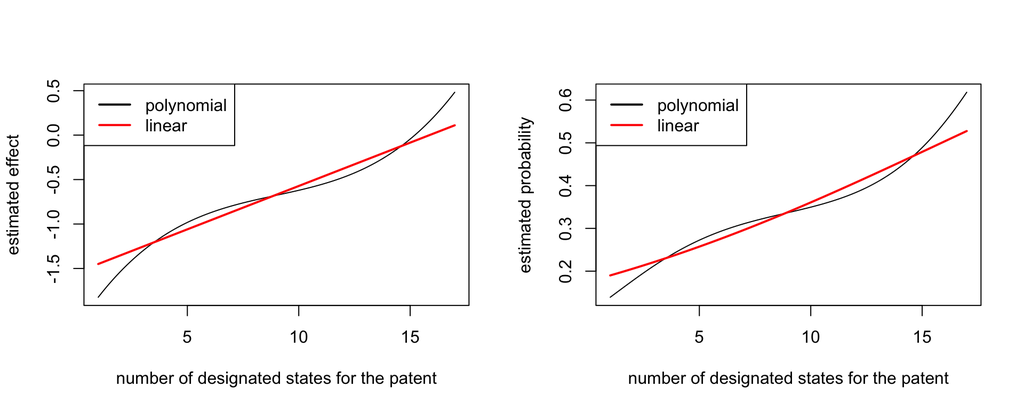

```r
par(mfrow = c(1, 2))
beta <- pat_opp_model$coefficients
constant <- beta[1] +
  beta[2] * mean(not_biopharm_patent_opp$year) +
  beta[3] * mean(not_biopharm_patent_opp$ncit) +
  beta[4] * mean(not_biopharm_patent_opp$nclaims) +
  beta[5] * mean(as.numeric(not_biopharm_patent_opp$ustwin)) +
  beta[6] * mean(as.numeric(not_biopharm_patent_opp$patus)) +
  beta[7] * mean(as.numeric(not_biopharm_patent_opp$patgsgr))

beta_poly <- pat_opp_poly_model$coefficients
poly_constant <- beta_poly[1] +
  beta_poly[2] * mean(not_biopharm_patent_opp$year) +
  beta_poly[3] * mean(not_biopharm_patent_opp$ncit) +
  beta_poly[4] * mean(not_biopharm_patent_opp$nclaims) +
  beta_poly[5] * mean(as.numeric(not_biopharm_patent_opp$ustwin)) +
  beta_poly[6] * mean(as.numeric(not_biopharm_patent_opp$patus)) +
  beta_poly[7] * mean(as.numeric(not_biopharm_patent_opp$patgsgr))

ncountry_seq <- seq(min(not_biopharm_patent_opp$ncountry), max(not_biopharm_patent_opp$ncountry), length.out = 100)
effect <- constant + beta[8] * ncountry_seq
poly_effect <- poly_constant + beta_poly[8] * ncountry_seq + beta_poly[9] * ncountry_seq ^ 2 + beta_poly[10] * ncountry_seq ^ 3
plot(
  NA,
  xlim = range(not_biopharm_patent_opp$ncountry),
  ylim = range(poly_effect),
  xlab = 'number of designated states for the patent',
  ylab = 'estimated effect'
)
lines(ncountry_seq, poly_effect)
lines(ncountry_seq, effect, col = 'red', lwd = 2)

legend(
  "topleft",
  legend = c("polynomial", "linear"),
  col = c("black", "red"),
  lwd = 2
)

poly_prob <- exp(poly_effect) / (1 + exp(poly_effect))
plot(
  NA,
  xlim  = range(not_biopharm_patent_opp$ncountry),
  ylim = range(poly_prob),
  xlab = 'number of designated states for the patent',
  ylab = 'estimated probability'
)
lines(ncountry_seq, poly_prob)
prob <- exp(effect) / (1 + exp(effect))
lines(ncountry_seq, prob, col = 'red', lwd = 2)
legend(
  "topleft",
  legend = c("polynomial", "linear"),
  col = c("black", "red"),
  lwd = 2
)
```

## Example 2.9 Hormone Therapy with Rats

We import the *Hormone Therapy with Rats* dataset from the [oficial page of the dataset](https://www.uni-goettingen.de/en/551625.html), as the other example:

```r
rats_url <- "https://www.uni-goettingen.de/de/document/download/3ac5a038b19297fb8609dfc28319cbb7.raw/rats.raw"

rats_dataset <- read.table(
  url(rats_url),
  header = 1,
  colClasses = c(
    "factor", "factor", "numeric",
    "integer", "numeric", "numeric",
    "factor", "factor", "factor",
    "numeric", "numeric", "numeric"
  )
)
rats_dataset$low <- rats_dataset$low == 1
rats_dataset$high <- rats_dataset$high == 1
rats_dataset$control <- rats_dataset$control == 1
summary(rats_dataset)
```

```
    subject    group      response          time      transf_time
 1      :  7   1:126   Min.   :66.60   Min.   : 50   Min.   :0.4055
 10     :  7   2:119   1st Qu.:74.62   1st Qu.: 60   1st Qu.:0.9163
 11     :  7   3:105   Median :77.88   Median : 80   Median :1.5041
 12     :  7           Mean   :77.53   Mean   : 80   Mean   :1.3814
 13     :  7           3rd Qu.:81.02   3rd Qu.:100   3rd Qu.:1.8718
 14     :  7           Max.   :86.83   Max.   :110   Max.   :2.0149
 (Other):308           NA's   :98
      eff              low             high          control
 Min.   :-0.90260   Mode :logical   Mode :logical   Mode :logical
 1st Qu.:-0.90260   FALSE:224       FALSE:231       FALSE:245
 Median : 0.17801   TRUE :126       TRUE :119       TRUE :105
 Mean   :-0.00475
 3rd Qu.: 0.72833
 Max.   : 0.72833
 NA's   :98
    lowtime          hightime       controltime
 Min.   :0.0000   Min.   :0.0000   Min.   :0.0000
 1st Qu.:0.0000   1st Qu.:0.0000   1st Qu.:0.0000
 Median :0.0000   Median :0.0000   Median :0.0000
 Mean   :0.4973   Mean   :0.4697   Mean   :0.4144
 3rd Qu.:1.2528   3rd Qu.:0.9163   3rd Qu.:0.9163
 Max.   :2.0149   Max.   :2.0149   Max.   :2.0149
```

We plot the timeseries of the rats divided in the three groups: **control**, **low** and **high** dose:

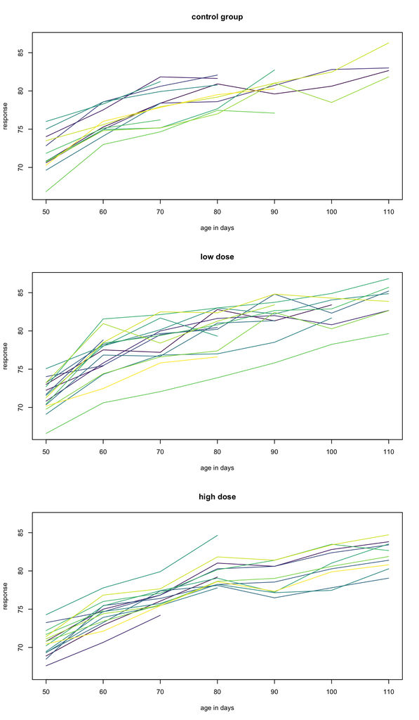

```r
par(mfrow = c(3, 1))

control_rats <- subset(rats_dataset, control)
low_rats <- subset(rats_dataset, low)
high_rats <- subset(rats_dataset, high)

library(viridis)
plot_rats_subsets <- function(rats_subset, title) {
  plot(
    NA,
    xlim = range(rats_dataset$time),
    ylim = range(na.omit(rats_dataset$response)),
    xlab = "age in days",
    ylab = "response",
    main = title
  )
  subjects <- unique(rats_subset$subject)
  for (i in seq_along(subjects)) {
    colors <- length(subjects)
    lines(
      subset(rats_subset, subject == subjects[i])$time,
      subset(rats_subset, subject == subjects[i])$response,
      col = viridis(colors)[i]
    )
  }
}

plot_rats_subsets(control_rats, "control group")
plot_rats_subsets(low_rats, "low dose")
plot_rats_subsets(high_rats, "high dose")
```

We add the transformed age:

$$t = \log(1 + (\text{age} - 45) / 10)$$

```r
rats_dataset$t <- log(1 + (rats_dataset$time - 45) / 10)
rats_dataset$C <- as.integer(rats_dataset$control)
rats_dataset$L <- as.integer(rats_dataset$low)
rats_dataset$H <- as.integer(rats_dataset$high)
summary(rats_dataset)
```

```
    subject    group      response          time      transf_time
 1      :  7   1:126   Min.   :66.60   Min.   : 50   Min.   :0.4055
 10     :  7   2:119   1st Qu.:74.62   1st Qu.: 60   1st Qu.:0.9163
 11     :  7   3:105   Median :77.88   Median : 80   Median :1.5041
 12     :  7           Mean   :77.53   Mean   : 80   Mean   :1.3814
 13     :  7           3rd Qu.:81.02   3rd Qu.:100   3rd Qu.:1.8718
 14     :  7           Max.   :86.83   Max.   :110   Max.   :2.0149
 (Other):308           NA's   :98
      eff              low             high          control
 Min.   :-0.90260   Mode :logical   Mode :logical   Mode :logical
 1st Qu.:-0.90260   FALSE:224       FALSE:231       FALSE:245
 Median : 0.17801   TRUE :126       TRUE :119       TRUE :105
 Mean   :-0.00475
 3rd Qu.: 0.72833
 Max.   : 0.72833
 NA's   :98
    lowtime          hightime       controltime           t
 Min.   :0.0000   Min.   :0.0000   Min.   :0.0000   Min.   :0.4055
 1st Qu.:0.0000   1st Qu.:0.0000   1st Qu.:0.0000   1st Qu.:0.9163
 Median :0.0000   Median :0.0000   Median :0.0000   Median :1.5041
 Mean   :0.4973   Mean   :0.4697   Mean   :0.4144   Mean   :1.3814
 3rd Qu.:1.2528   3rd Qu.:0.9163   3rd Qu.:0.9163   3rd Qu.:1.8718
 Max.   :2.0149   Max.   :2.0149   Max.   :2.0149   Max.   :2.0149

       C             L              H
 Min.   :0.0   Min.   :0.00   Min.   :0.00
 1st Qu.:0.0   1st Qu.:0.00   1st Qu.:0.00
 Median :0.0   Median :0.00   Median :0.00
 Mean   :0.3   Mean   :0.36   Mean   :0.34
 3rd Qu.:1.0   3rd Qu.:1.00   3rd Qu.:1.00
 Max.   :1.0   Max.   :1.00   Max.   :1.00
```

And we fit the model:

$$y_{ij} = \beta_{0} + \gamma_{0i} + \beta_{1} L_{i} \cdot t_{ij} +
\beta_{2} H_{i} \cdot t_{ij} + \beta_{3} C_{i} \cdot t_{ij} +
\gamma_{1i} \cdot t_{ij} + \epsilon_{ij}$$

With $\epsilon_{ij} \sim N(0, \sigma^2)$ as in all these examples. And $\gamma_{0i}$ and $\gamma_{1i}$ are random effects associated with the subjects following:

$$\gamma_{0i} \sim N(0, \tau_{0}^2) \wedge \gamma_{1i} \sim N(0,
\tau_{1}^2)$$

## Example 2.10 Hormone Therapy with Rats

```r
library(lme4)
rats_model <- lmer(
  response ~ L:t + H:t + C:t + (1 + t | subject), data = rats_dataset
)
```

```
boundary (singular) fit: see help('isSingular')
```

```r
summary(rats_model)
```

```
Linear mixed model fit by REML ['lmerMod']
Formula: response ~ L:t + H:t + C:t + (1 + t | subject)
   Data: rats_dataset

REML criterion at convergence: 932.4

Scaled residuals:
     Min       1Q   Median       3Q      Max
-2.25589 -0.66674 -0.01327  0.58310  2.89228

Random effects:
 Groups   Name        Variance Std.Dev. Corr
 subject  (Intercept) 3.429240 1.85182
          t           0.001081 0.03288  1.00
 Residual             1.444602 1.20192
Number of obs: 252, groups:  subject, 50

Fixed effects:
            Estimate Std. Error t value
(Intercept)  68.6061     0.3272  209.70
L:t           7.5045     0.2274   32.99
t:H           6.8750     0.2301   29.88
t:C           7.3178     0.2836   25.80

Correlation of Fixed Effects:
    (Intr) L:t    t:H
L:t -0.336
t:H -0.325  0.109
t:C -0.316  0.106  0.103
optimizer (nloptwrap) convergence code: 0 (OK)
boundary (singular) fit: see help('isSingular')
```

And the simpler model eliminating the subject-specific term $\tau_{1i} \cdot t_{ij}$:

$$y_{ij} = \beta_{0} + \gamma_{0i} + \beta_{1} L_{i} \cdot t_{ij} +
\beta_{2} H_{i} \cdot t_{ij} + \beta_{3} C_{i} \cdot t_{ij} +
\epsilon_{ij}$$

```r
simple_rats_model <- lmer(
  response ~ L:t + H:t + C:t + (1 | subject), data = rats_dataset
)
summary(simple_rats_model)
```

```
Linear mixed model fit by REML ['lmerMod']
Formula: response ~ L:t + H:t + C:t + (1 | subject)
   Data: rats_dataset

REML criterion at convergence: 932.4

Scaled residuals:
     Min       1Q   Median       3Q      Max
-2.25575 -0.65899 -0.01164  0.58358  2.88309

Random effects:
 Groups   Name        Variance Std.Dev.
 subject  (Intercept) 3.565    1.888
 Residual             1.445    1.202
Number of obs: 252, groups:  subject, 50

Fixed effects:
            Estimate Std. Error t value
(Intercept)  68.6074     0.3312  207.13
L:t           7.5069     0.2252   33.34
t:H           6.8711     0.2276   30.19
t:C           7.3139     0.2808   26.05

Correlation of Fixed Effects:
    (Intr) L:t    t:H
L:t -0.351
t:H -0.340  0.119
t:C -0.327  0.115  0.111
```

We then plot a kernel density estimator with a normal distribution for those values. Alongside a normal quantity plot:

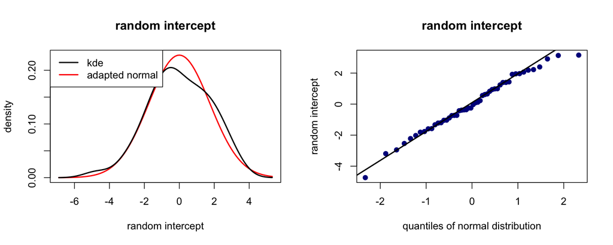

```r
par(mfrow = c(1, 2))
tau_0i <- ranef(rats_model)$subject[, 1]

kde <- density(tau_0i)

tau_seq <- seq(min(kde$x), max(kde$x), length.out = 100)

plot(
  x = tau_seq,
  y = dnorm(tau_seq, mean = mean(tau_0i), sd = sd(tau_0i)),
  type = 'l',
  main = 'random intercept',
  xlab = 'random intercept',
  ylab = 'density',
  col = 'red',
  lwd = 2
)

lines(
  x = kde$x,
  y = kde$y,
  col = 'black',
  lwd = 2
)

legend(
  'topleft',
  legend = c('kde', 'adapted normal'),
  col = c('black', 'red'),
  lwd = 2
)

qqnorm(
  tau_0i,
  main = 'random intercept',
  xlab = 'quantiles of normal distribution',
  ylab = 'random intercept',
  pch = 19,
  col = "darkblue"
)

# Add reference line
qqline(
  tau_0i,
  col = "black",
  lwd = 2
)
```

## Example 2.11 Malnutrition in Zambia

Import data from script:

```r
source("import_data/malnutrition_zambia.R")
```

*To be continued…*